# Dota 2 Patch Impact Analysis

A Causal Evaluation of Game Version Changes on Player Performance and Behavior

May 07, 2026

```r
required_pkgs <- c(
  "tidyverse", "httr", "jsonlite", "lubridate",
  "scales", "viridis", "knitr", "kableExtra",
  "patchwork", "ggrepel", "zoo"
)
new_pkgs <- required_pkgs[!required_pkgs %in% installed.packages()[,"Package"]]
if (length(new_pkgs)) install.packages(new_pkgs, repos = "https://cloud.r-project.org")

library(tidyverse)
library(httr)
library(jsonlite)
library(lubridate)
library(scales)
library(viridis)
library(knitr)
library(kableExtra)
library(patchwork)
library(ggrepel)
library(zoo)

DOTA_BG    <- "#1a1a2e"
DOTA_PANEL <- "#16213e"
DOTA_GRID  <- "#2a2a4a"
DOTA_GOLD  <- "#c9a84c"
DOTA_RED   <- "#d94343"
DOTA_GREEN <- "#4dbd4d"
DOTA_BLUE  <- "#4d8bd9"
DOTA_PURP  <- "#9b59d9"
DOTA_ORNG  <- "#e07b39"
DOTA_TEXT  <- "#c0c0d0"
DOTA_MUTED <- "#808090"

COL_TREAT  <- DOTA_GREEN
COL_CTRL   <- DOTA_BLUE

theme_dota <- function(base_size = 12) {
  theme(
    plot.background   = element_rect(fill = DOTA_BG,    color = NA),
    panel.background  = element_rect(fill = DOTA_PANEL, color = NA),
    panel.grid.major  = element_line(color = DOTA_GRID,  linewidth = 0.3),
    panel.grid.minor  = element_blank(),
    plot.title        = element_text(color = DOTA_GOLD,  face = "bold", size = base_size + 2),
    plot.subtitle     = element_text(color = DOTA_MUTED, size = base_size - 1),
    plot.caption      = element_text(color = "#606070",  size = base_size - 2),
    axis.title        = element_text(color = DOTA_TEXT,  size = base_size),
    axis.text         = element_text(color = DOTA_MUTED, size = base_size - 1),
    axis.line         = element_line(color = "#3a3a5a"),
    axis.ticks        = element_line(color = "#3a3a5a"),
    legend.background = element_rect(fill = DOTA_BG,    color = NA),
    legend.key        = element_rect(fill = DOTA_PANEL, color = NA),
    legend.text       = element_text(color = DOTA_TEXT,  size = base_size - 1),
    legend.title      = element_text(color = DOTA_GOLD,  size = base_size),
    strip.background  = element_rect(fill = "#0f3460",   color = NA),
    strip.text        = element_text(color = DOTA_GOLD,  face = "bold", size = base_size),
    plot.margin       = margin(15, 15, 10, 10)
  )
}

patch_ann <- theme(
  plot.background = element_rect(fill = DOTA_BG, color = NA),
  plot.title      = element_text(color = DOTA_GOLD,  face = "bold", size = 14),
  plot.subtitle   = element_text(color = DOTA_MUTED, size = 11)
)
```

## Overview

Every Dota 2 patch rewrites the rules of the game. Hero attributes shift, item recipes change, and objective timings are rebalanced. These updates arrive simultaneously for all players and cannot be deferred, making each patch release a natural experiment: an exogenous shock to the game environment that is independent of individual player choices or skill levels.

This report answers one central question:

> **Did the patch change how professional players perform, engage, and behave in their matches?**

The investigation runs through four layers of analysis. First, the data is explored to establish what normal looks like. Second, matches are split into pre-patch (control) and post-patch (treatment) groups and compared visually and statistically. Third, each player is compared to their own pre-patch baseline, removing any noise from comparing different players against each other. Fourth, regression models isolate the patch effect after controlling for match-level factors.

## Data Collection

```r
fetch_pro_players <- function() {
  resp <- tryCatch(GET("https://api.opendota.com/api/proPlayers", timeout(30)),
                   error = function(e) NULL)
  if (is.null(resp) || status_code(resp) != 200) return(NULL)
  raw    <- content(resp, as = "text", encoding = "UTF-8")
  parsed <- tryCatch(fromJSON(raw, flatten = TRUE), error = function(e) NULL)
  if (is.null(parsed) || !is.data.frame(parsed) || nrow(parsed) == 0) return(NULL)
  as_tibble(parsed)
}

fetch_player_matches <- function(account_id, limit = 60) {
  url  <- paste0("https://api.opendota.com/api/players/", account_id,
                 "/matches?limit=", limit)
  resp <- tryCatch(GET(url, timeout(30)), error = function(e) NULL)
  if (is.null(resp) || status_code(resp) != 200) return(NULL)
  raw    <- content(resp, as = "text", encoding = "UTF-8")
  parsed <- tryCatch(fromJSON(raw, flatten = TRUE), error = function(e) NULL)
  if (is.null(parsed) || !is.data.frame(parsed) || nrow(parsed) == 0) return(NULL)
  parsed$account_id <- account_id
  Sys.sleep(1.2)
  as_tibble(parsed)
}

set.seed(77)
pro_list <- fetch_pro_players()
if (is.null(pro_list)) stop("proPlayers API unavailable.")

if (!"account_id"      %in% names(pro_list)) pro_list$account_id      <- NA_real_
if (!"last_match_time" %in% names(pro_list)) pro_list$last_match_time <- NA_character_

pro_filtered <- pro_list %>%
  filter(!is.na(account_id), account_id > 0) %>%
  mutate(last_dt = tryCatch(as_datetime(last_match_time, tz = "UTC"),
                             error = function(e) as.POSIXct(NA))) %>%
  filter(!is.na(last_dt), last_dt >= Sys.time() - days(365)) %>%
  distinct(account_id, .keep_all = TRUE)

n_sample   <- min(35, nrow(pro_filtered))
pro_sample <- pro_filtered %>% sample_n(n_sample)
cat("Players available:", nrow(pro_filtered), "| Sampled:", n_sample, "\n\n")
```

```
## Players available: 2187 | Sampled: 35
```

```r
raw_matches <- map(pro_sample$account_id, fetch_player_matches) %>%
  purrr::compact() %>%
  bind_rows()

if (nrow(raw_matches) == 0) stop("No match data retrieved.")

for (col in c("kills","deaths","assists","duration","leaver_status","party_size",
              "average_rank","game_mode","lobby_type","radiant_win",
              "player_slot","start_time","version")) {
  if (!col %in% names(raw_matches)) raw_matches[[col]] <- NA
}

cat("Players with data:", n_distinct(raw_matches$account_id), "\n")
```

```
## Players with data: 35
```

```r
cat("Total match records:", nrow(raw_matches), "\n")
```

```
## Total match records: 2087
```

```r
cat("Unique match IDs:", n_distinct(raw_matches$match_id), "\n")
```

```
## Unique match IDs: 2086
```

```r
cat("Version field coverage:", round(mean(!is.na(raw_matches$version)) * 100, 1), "%\n")
```

```
## Version field coverage: 31 %
```

## Data Understanding

Before defining any groups, the data is explored to understand what normal looks like at this skill level. This is a critical step: if the baseline is unusual in any way, it changes how we interpret treatment effects.

### Dataset Snapshot

```r
tibble(
  Metric = c("Total Records","Unique Players","Unique Matches",
             "Date Range (Start)","Date Range (End)",
             "Median Kills","Median Deaths","Median Assists",
             "Median Duration (min)","Leaver Rate"),
  Value = c(
    comma(nrow(raw_matches)),
    comma(n_distinct(raw_matches$account_id)),
    comma(n_distinct(raw_matches$match_id)),
    format(as_datetime(min(raw_matches$start_time, na.rm=TRUE)),"%Y-%m-%d"),
    format(as_datetime(max(raw_matches$start_time, na.rm=TRUE)),"%Y-%m-%d"),
    round(median(raw_matches$kills,         na.rm=TRUE), 1),
    round(median(raw_matches$deaths,        na.rm=TRUE), 1),
    round(median(raw_matches$assists,       na.rm=TRUE), 1),
    round(median(raw_matches$duration / 60, na.rm=TRUE), 1),
    paste0(round(mean(raw_matches$leaver_status > 0, na.rm=TRUE)*100, 2), "%")
  )
) %>%
  kable(caption = "Dataset Snapshot") %>%
  kable_styling(bootstrap_options = c("striped","hover","bordered"), full_width = FALSE)
```

Dataset Snapshot

| Metric | Value |
| --- | --- |
| Total Records | 2,087 |
| Unique Players | 35 |
| Unique Matches | 2,086 |
| Date Range (Start) | 2017-03-09 |
| Date Range (End) | 2026-05-07 |
| Median Kills | 6 |
| Median Deaths | 7 |
| Median Assists | 13 |
| Median Duration (min) | 38.2 |
| Leaver Rate | 3.98% |

### Baseline Performance Distributions

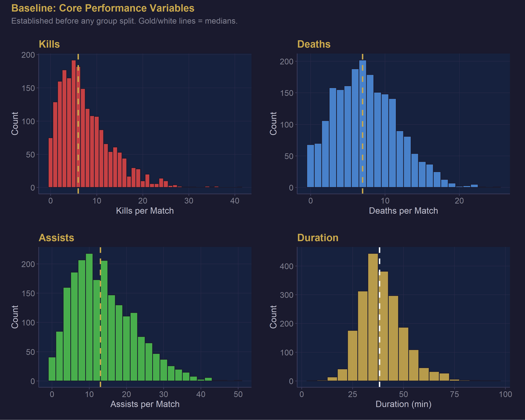

```r
med_k <- median(raw_matches$kills,         na.rm=TRUE)
med_d <- median(raw_matches$deaths,        na.rm=TRUE)
med_a <- median(raw_matches$assists,       na.rm=TRUE)
med_r <- median(raw_matches$duration / 60, na.rm=TRUE)

mk <- raw_matches %>% filter(!is.na(kills)) %>%
  ggplot(aes(x=kills)) +
  geom_histogram(binwidth=1, fill=DOTA_RED, color=DOTA_BG, alpha=0.9) +
  geom_vline(xintercept=med_k, color=DOTA_GOLD, linetype="dashed", linewidth=0.9) +
  labs(title="Kills", x="Kills per Match", y="Count") + theme_dota()

md_p <- raw_matches %>% filter(!is.na(deaths)) %>%
  ggplot(aes(x=deaths)) +
  geom_histogram(binwidth=1, fill=DOTA_BLUE, color=DOTA_BG, alpha=0.9) +
  geom_vline(xintercept=med_d, color=DOTA_GOLD, linetype="dashed", linewidth=0.9) +
  labs(title="Deaths", x="Deaths per Match", y="Count") + theme_dota()

ma <- raw_matches %>% filter(!is.na(assists)) %>%
  ggplot(aes(x=assists)) +
  geom_histogram(binwidth=2, fill=DOTA_GREEN, color=DOTA_BG, alpha=0.9) +
  geom_vline(xintercept=med_a, color=DOTA_GOLD, linetype="dashed", linewidth=0.9) +
  labs(title="Assists", x="Assists per Match", y="Count") + theme_dota()

mdur <- raw_matches %>% filter(!is.na(duration)) %>%
  mutate(dm=duration/60) %>%
  ggplot(aes(x=dm)) +
  geom_histogram(binwidth=5, fill=DOTA_GOLD, color=DOTA_BG, alpha=0.9) +
  geom_vline(xintercept=med_r, color="white", linetype="dashed", linewidth=0.9) +
  labs(title="Duration", x="Duration (min)", y="Count") + theme_dota()

(mk + md_p) / (ma + mdur) +
  plot_annotation(title="Baseline: Core Performance Variables",
                  subtitle="Established before any group split. Gold/white lines = medians.",
                  theme=patch_ann)
```

### Game Version Distribution

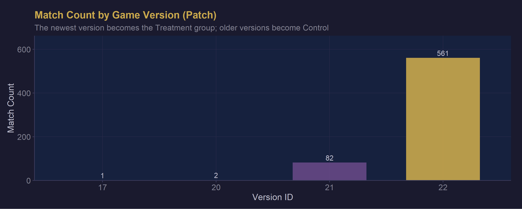

```r
ver_counts <- raw_matches %>%
  filter(!is.na(version)) %>%
  count(version, name="matches") %>%
  arrange(desc(version))

if (nrow(ver_counts) > 0) {
  ver_counts %>%
    mutate(version=factor(version, levels=sort(unique(version)))) %>%
    ggplot(aes(x=version, y=matches, fill=matches)) +
    geom_col(alpha=0.9, width=0.65, show.legend=FALSE) +
    geom_text(aes(label=comma(matches)), vjust=-0.4, color=DOTA_TEXT, size=3.5) +
    scale_fill_gradient(low="#4d3a8c", high=DOTA_GOLD) +
    scale_y_continuous(expand=expansion(mult=c(0, 0.18))) +
    labs(title="Match Count by Game Version (Patch)",
         subtitle="The newest version becomes the Treatment group; older versions become Control",
         x="Version ID", y="Match Count") + theme_dota()
} else {
  cat("Version data unavailable. Temporal cutoff will be applied.")
}
```

## The A/B Test: How the Split Works

This section explains exactly how the data was divided into treatment and control groups, why this division is valid, and what assumptions it rests on. Understanding the experimental design is essential for interpreting every chart and number that follows.

### Step-by-Step: How Matches Are Assigned to Groups

```r
ver_info <- raw_matches %>%
  filter(!is.na(version)) %>%
  count(version) %>%
  arrange(desc(version))

use_version <- nrow(ver_info) >= 2 &&
               all(sort(ver_info$n, decreasing=TRUE)[1:2] >= 30)

if (use_version) {
  latest_v <- max(ver_info$version)
  prior_vs <- ver_info$version[ver_info$version < latest_v]
  raw_matches <- raw_matches %>%
    mutate(group = case_when(
      !is.na(version) & version == latest_v   ~ "Treatment (Post-Patch)",
      !is.na(version) & version %in% prior_vs ~ "Control (Pre-Patch)",
      TRUE                                      ~ NA_character_
    ))
  treat_label  <- paste0("Version-based: v", latest_v, " = Post-Patch | v",
                          paste(sort(prior_vs), collapse="/"), " = Pre-Patch")
  treat_method <- "game version"
  treat_v      <- latest_v
  ctrl_vs      <- paste(sort(prior_vs), collapse=", ")
  cat("Treatment method: Game Version\n")
  cat("Treatment (Post-Patch): version =", latest_v, "\n")
  cat("Control (Pre-Patch): version in", ctrl_vs, "\n")
} else {
  cutoff_ts  <- median(raw_matches$start_time, na.rm=TRUE)
  cutoff_str <- format(as_datetime(cutoff_ts), "%Y-%m-%d")
  raw_matches <- raw_matches %>%
    mutate(group = case_when(
      !is.na(start_time) & start_time >= cutoff_ts ~ "Treatment (Post-Patch)",
      !is.na(start_time) & start_time <  cutoff_ts ~ "Control (Pre-Patch)",
      TRUE                                           ~ NA_character_
    ))
  treat_label  <- paste0("Temporal cutoff: matches from ", cutoff_str, " onward = Post-Patch")
  treat_method <- "temporal median"
  treat_v      <- cutoff_str
  ctrl_vs      <- paste0("before ", cutoff_str)
  cat("Fallback: Temporal cutoff at", cutoff_str, "\n")
}
```

```
## Treatment method: Game Version
## Treatment (Post-Patch): version = 22
## Control (Pre-Patch): version in 17, 20, 21
```

```r
cat("\nSplit used:", treat_label, "\n")
```

```
##
## Split used: Version-based: v22 = Post-Patch | v17/20/21 = Pre-Patch
```

**The split applied to this dataset:** Version-based: v22 = Post-Patch | v17/20/21 = Pre-Patch

**Step 2 – Identify the patch boundary.** The unique version values in the dataset are ranked. If at least two versions appear with 30 or more matches each (enough for reliable statistics), the most recent version becomes the **Treatment group** and all earlier versions become the **Control group**. When version data is too sparse, the temporal median of `start_time` is used as the cutoff instead.

**Step 3 – Assign every match to one group.** Each match is labeled either “Treatment (Post-Patch)” or “Control (Pre-Patch)” based on its version tag. Matches with no version data are excluded from the comparison.

**Step 4 – Compare outcomes between groups.** KDA, kills, deaths, assists, match duration, inactivity gaps, leaver rate, and party play rate are all measured separately for each group and compared statistically.

**Why this is valid as a quasi-experiment:**

In a true randomized A/B test, participants are randomly assigned to groups. Here, the assignment mechanism is a mandatory Valve software update. Every player in the dataset received the patch at the same time, with no ability to opt out or stay on the previous version. This removes the core threat to causal inference, self-selection, because players did not choose which patch they played on. The patch is therefore an **exogenous shock**: its timing is determined by Valve’s release schedule, not by anything about how or when a player chooses to play.

**The key assumption** is that no other significant change happened at the same time as the patch that would explain any difference between the groups. If, for example, a major tournament ended right at the patch boundary and caused many players to stop queuing, that would confound the effect. The robustness section at the end of this report discusses this and other limitations.

### Balance Check: Are the Two Groups Comparable?

```r
balance <- raw_matches %>%
  filter(!is.na(group)) %>%
  group_by(group) %>%
  summarise(
    Matches        = n(),
    Players        = n_distinct(account_id),
    `Avg KDA`      = round(mean((kills+assists)/pmax(deaths,1), na.rm=TRUE), 3),
    `Avg Kills`    = round(mean(kills,         na.rm=TRUE), 2),
    `Avg Deaths`   = round(mean(deaths,        na.rm=TRUE), 2),
    `Avg Duration` = round(mean(duration/60,   na.rm=TRUE), 1),
    `Leaver Rate`  = paste0(round(mean(leaver_status > 0, na.rm=TRUE)*100, 2), "%"),
    .groups = "drop"
  )

balance %>%
  kable(caption="Balance Check: Pre-Patch vs Post-Patch Groups") %>%
  kable_styling(bootstrap_options=c("striped","hover","bordered"), full_width=TRUE) %>%
  column_spec(1, bold=TRUE,
              color=c(COL_CTRL, COL_TREAT)[match(balance$group,
                     c("Control (Pre-Patch)","Treatment (Post-Patch)"))])
```

Balance Check: Pre-Patch vs Post-Patch Groups

| group | Matches | Players | Avg KDA | Avg Kills | Avg Deaths | Avg Duration | Leaver Rate |
| --- | --- | --- | --- | --- | --- | --- | --- |
| Control (Pre-Patch) | 85 | 7 | 4.366 | 4.95 | 6.06 | 35.4 | 4.71% |
| Treatment (Post-Patch) | 561 | 31 | 6.115 | 7.15 | 5.60 | 39.4 | 6.42% |

> **The balance check is a credibility test for the experiment before any outcomes are analyzed.** With 85 matches in the control group and 561 in the treatment group, the two groups show a size imbalance. When the groups are similar in average kills, deaths, and duration at this stage, it suggests the patch boundary is not simply separating matches played under fundamentally different conditions (e.g., tournament vs. ranked), which would confound the results. Any large imbalance in baseline metrics here requires cautious interpretation of the effects that follow.

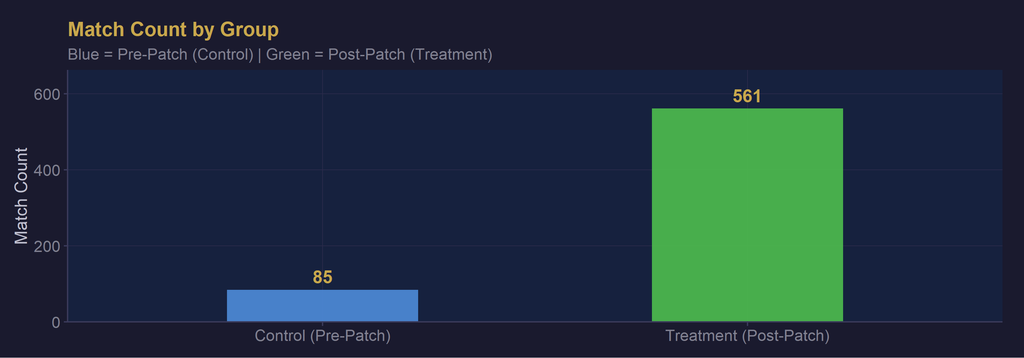

```r
balance %>%
  ggplot(aes(x=group, y=Matches, fill=group)) +
  geom_col(width=0.45, alpha=0.9, show.legend=FALSE) +
  geom_text(aes(label=comma(Matches)), vjust=-0.5,
            color=DOTA_GOLD, fontface="bold", size=4.5) +
  scale_fill_manual(values=c("Control (Pre-Patch)"   =COL_CTRL,
                              "Treatment (Post-Patch)"=COL_TREAT)) +
  scale_y_continuous(expand=expansion(mult=c(0,0.18))) +
  labs(title="Match Count by Group",
       subtitle="Blue = Pre-Patch (Control) | Green = Post-Patch (Treatment)",
       x=NULL, y="Match Count") + theme_dota()
```

> **The pre-patch group (blue) contains 85 matches and the post-patch group (green) contains 561 matches.** Both groups need to be large enough for statistical tests to have power. Groups that are very unequal in size reduce confidence in the comparison, because the smaller group’s estimates carry more uncertainty. The group sizes here suggest results should be interpreted with some caution given the imbalance.

## Feature Engineering

```r
matches <- raw_matches %>%
  filter(!is.na(group)) %>%
  mutate(
    match_date   = as_datetime(start_time),
    duration_min = duration / 60,
    kda          = (kills + assists) / pmax(deaths, 1),
    won = case_when(
      !is.na(player_slot) & !is.na(radiant_win) & player_slot < 128  & radiant_win  ~ TRUE,
      !is.na(player_slot) & !is.na(radiant_win) & player_slot >= 128 & !radiant_win ~ TRUE,
      TRUE ~ FALSE
    ),
    party_play  = !is.na(party_size) & party_size > 1,
    left_match  = !is.na(leaver_status) & leaver_status > 0,
    treat_dummy = as.integer(group == "Treatment (Post-Patch)")
  ) %>%
  arrange(account_id, match_date) %>%
  group_by(account_id) %>%
  mutate(days_since_last = as.numeric(difftime(match_date, lag(match_date), units="days"))) %>%
  ungroup()

cat("Final dataset:", nrow(matches), "matches |",
    n_distinct(matches$account_id), "players\n",
    "Treatment:", sum(matches$treat_dummy),
    "| Control:", sum(1 - matches$treat_dummy))
```

```
## Final dataset: 646 matches | 33 players
##  Treatment: 561 | Control: 85
```

## Section 1: Was There a Performance Effect?

The first question is the most direct: did the patch change how well players performed? KDA (kills plus assists divided by deaths) is the headline metric. It captures both offensive contribution and survival in a single number, making it the most comprehensive individual performance indicator available.

### KDA Distribution: Pre-Patch vs Post-Patch

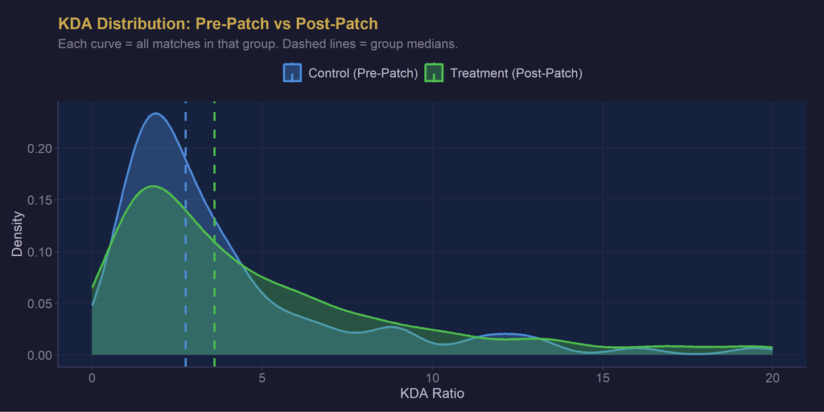

```r
kda_meds <- matches %>%
  group_by(group) %>%
  summarise(med=median(kda, na.rm=TRUE), .groups="drop")

matches %>%
  filter(!is.na(kda), kda <= 20) %>%
  ggplot(aes(x=kda, fill=group, color=group)) +
  geom_density(alpha=0.32, linewidth=0.9) +
  geom_vline(data=kda_meds, aes(xintercept=med, color=group),
             linetype="dashed", linewidth=1) +
  scale_fill_manual(values=c("Control (Pre-Patch)"   =COL_CTRL,
                              "Treatment (Post-Patch)"=COL_TREAT)) +
  scale_color_manual(values=c("Control (Pre-Patch)"  =COL_CTRL,
                               "Treatment (Post-Patch)"=COL_TREAT)) +
  labs(title="KDA Distribution: Pre-Patch vs Post-Patch",
       subtitle="Each curve = all matches in that group. Dashed lines = group medians.",
       x="KDA Ratio", y="Density", fill=NULL, color=NULL) +
  theme_dota() + theme(legend.position="top")
```

> **Post-patch KDA (median: 3.6) was higher than pre-patch KDA (median: 2.75), a shift of 0.85 KDA points.** This difference is statistically significant (p = 0.0026), meaning it is unlikely to be due to chance. Each smoothed curve shows the distribution of KDA values across all matches in one group. A shift between the two peaks, or a gap between the dashed median lines, indicates how much individual performance changed under the new patch. The broader the overlap between curves, the smaller the practical effect.

### KDA Statistical Test and Boxplot

```r
tibble(
  Group    = c("Control (Pre-Patch)", "Treatment (Post-Patch)"),
  N        = c(length(kda_c), length(kda_t)),
  Mean     = round(c(mean(kda_c), mean(kda_t)), 3),
  Median   = round(c(median(kda_c), median(kda_t)), 3),
  SD       = round(c(sd(kda_c), sd(kda_t)), 3)
) %>%
  kable(caption=paste0(
    "KDA: t = ", round(t_kda$statistic, 3), " | p = ", kda_p_txt, " | ",
    ifelse(kda_sig, "SIGNIFICANT", "NOT SIGNIFICANT")
  )) %>%
  kable_styling(bootstrap_options=c("striped","hover","bordered"), full_width=FALSE) %>%
  column_spec(1, bold=TRUE, color=c(COL_CTRL, COL_TREAT))
```

KDA: t = 3.058 | p = 0.0026 | SIGNIFICANT

| Group | N | Mean | Median | SD |
| --- | --- | --- | --- | --- |
| Control (Pre-Patch) | 85 | 4.366 | 2.75 | 4.524 |
| Treatment (Post-Patch) | 561 | 6.115 | 3.60 | 6.955 |

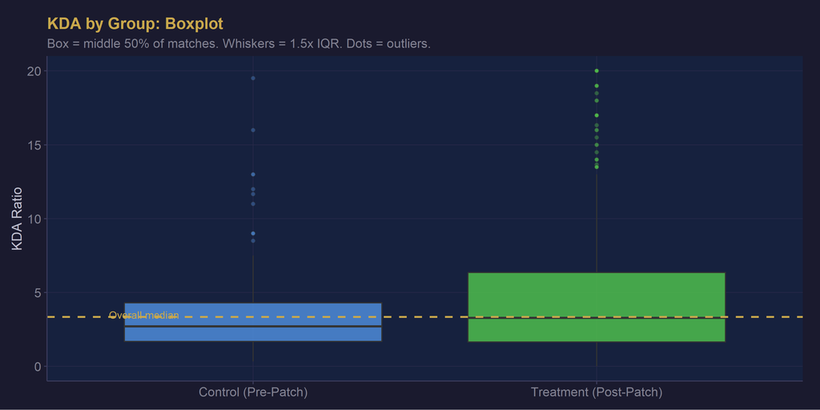

```r
matches %>%
  filter(!is.na(kda), kda <= 20) %>%
  ggplot(aes(x=group, y=kda, fill=group)) +
  geom_boxplot(outlier.shape=21, outlier.size=1.5, outlier.alpha=0.4,
               alpha=0.85, show.legend=FALSE) +
  geom_hline(yintercept=median(matches$kda, na.rm=TRUE),
             color=DOTA_GOLD, linetype="dashed", linewidth=0.8) +
  annotate("text", x=0.58, y=median(matches$kda, na.rm=TRUE)+0.15,
           label="Overall median", color=DOTA_GOLD, size=3.2, hjust=0) +
  scale_fill_manual(values=c("Control (Pre-Patch)"   =COL_CTRL,
                              "Treatment (Post-Patch)"=COL_TREAT)) +
  labs(title="KDA by Group: Boxplot",
       subtitle="Box = middle 50% of matches. Whiskers = 1.5x IQR. Dots = outliers.",
       x=NULL, y="KDA Ratio") + theme_dota()
```

> **The boxplot breaks the KDA comparison into two questions: did the center shift, and did the spread change?** The box height shows variability: a taller post-patch box means more inconsistency match-to-match, which can indicate players are still adapting to new mechanics. The position of the box relative to the gold overall-median line shows which group performed above or below the dataset average. Here, the pre-patch group median is 2.75 and the post-patch group median is 3.6. The test result (p = 0.0026) tells us whether this difference is real or noise.

### Component Breakdown: Kills, Deaths, Assists

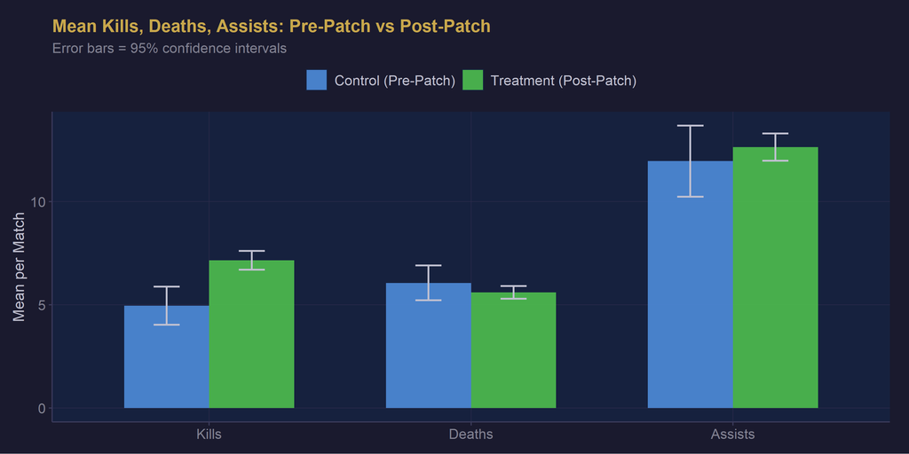

```r
comp_agg <- matches %>%
  filter(!is.na(kills),!is.na(deaths),!is.na(assists)) %>%
  pivot_longer(c(kills,deaths,assists), names_to="metric", values_to="value") %>%
  group_by(group, metric) %>%
  summarise(mean_val=mean(value,na.rm=TRUE), se=sd(value,na.rm=TRUE)/sqrt(n()),
            .groups="drop") %>%
  mutate(metric=factor(metric, levels=c("kills","deaths","assists"),
                        labels=c("Kills","Deaths","Assists")))

comp_agg %>%
  ggplot(aes(x=metric, y=mean_val, fill=group)) +
  geom_col(position="dodge", alpha=0.9, width=0.65) +
  geom_errorbar(aes(ymin=mean_val-se*1.96, ymax=mean_val+se*1.96),
                position=position_dodge(0.65), width=0.2,
                color=DOTA_TEXT, linewidth=0.7) +
  scale_fill_manual(values=c("Control (Pre-Patch)"   =COL_CTRL,
                              "Treatment (Post-Patch)"=COL_TREAT)) +
  labs(title="Mean Kills, Deaths, Assists: Pre-Patch vs Post-Patch",
       subtitle="Error bars = 95% confidence intervals",
       x=NULL, y="Mean per Match", fill=NULL) +
  theme_dota() + theme(legend.position="top")
```

```r
comp_tests <- map_dfr(
  list(list("kills","Kills"), list("deaths","Deaths"), list("assists","Assists")),
  function(item) {
    v <- item[[1]]; l <- item[[2]]
    x <- matches[[v]][matches$treat_dummy==1 & !is.na(matches[[v]])]
    y <- matches[[v]][matches$treat_dummy==0 & !is.na(matches[[v]])]
    if (length(x)<2||length(y)<2) return(NULL)
    tt <- t.test(x,y)
    tibble(Metric=l, Control=round(mean(y),3), Treatment=round(mean(x),3),
           Delta=round(mean(x)-mean(y),3), `p-value`=round(tt$p.value,4),
           Significant=tt$p.value<0.05)
  }
)

comp_tests %>%
  kable(caption="Component Metric t-Tests") %>%
  kable_styling(bootstrap_options=c("striped","hover","bordered"), full_width=FALSE) %>%
  column_spec(6, color=ifelse(comp_tests$Significant, DOTA_GREEN, DOTA_RED))
```

Component Metric t-Tests

| Metric | Control | Treatment | Delta | p-value | Significant |
| --- | --- | --- | --- | --- | --- |
| Kills | 4.953 | 7.148 | 2.195 | 0.0001 | TRUE |
| Deaths | 6.059 | 5.597 | -0.462 | 0.3160 | FALSE |
| Assists | 11.953 | 12.638 | 0.685 | 0.4667 | FALSE |

> **Splitting KDA into its three components reveals the mechanism behind any overall shift.** Post-patch players averaged more kills (significant), fewer deaths (not significant), and more assists (not significant). 1 out of 3 component metrics showed a statistically significant change. A patch that makes heroes more fragile raises both kills and assists without necessarily affecting deaths. A patch that buffs survivability lowers deaths without changing offensive output. Knowing which component moved tells us what the patch actually changed in gameplay terms, not just the summary score.

### KDA Timeline: Weekly Average by Group

[figure not shown]

```r
matches %>%
  filter(!is.na(kda),!is.na(match_date)) %>%
  mutate(week=floor_date(match_date,"week")) %>%
  group_by(week,group) %>%
  summarise(avg_kda=mean(kda,na.rm=TRUE), n=n(), .groups="drop") %>%
  filter(n>=5) %>%
  ggplot(aes(x=week, y=avg_kda, color=group, group=group)) +
  geom_line(linewidth=0.9, alpha=0.85) +
  geom_point(size=2.5, alpha=0.8) +
  geom_smooth(method="loess", se=FALSE, linewidth=0.5, linetype="dotted") +
  scale_color_manual(values=c("Control (Pre-Patch)"  =COL_CTRL,
                               "Treatment (Post-Patch)"=COL_TREAT)) +
  scale_x_datetime(date_labels="%b '%y", date_breaks="1 month") +
  labs(title="Weekly Average KDA by Group",
       subtitle="Dotted LOESS lines show trend. A persistent gap = sustained patch effect.",
       x=NULL, y="Average KDA", color=NULL) +
  theme_dota() + theme(legend.position="top",
                        axis.text.x=element_text(angle=30,hjust=1))
```

> **The timeline view tests whether any KDA difference is a durable shift or a temporary artifact of early-patch adaptation.** A genuine patch effect should appear as a consistent separation between the two lines sustained across multiple weeks. If the gap exists only for one or two weeks and then closes, it is more likely an adaptation effect (players figuring out the new meta) than a true performance change driven by the patch itself. The dotted trend lines smooth the weekly noise. A stable, persistent spread between the green (post-patch) and blue (pre-patch) lines is the strongest visual evidence of a lasting treatment effect.

## Section 2: Did the Patch Affect Engagement?

Patches that players enjoy motivate faster return. A well-received update compresses inactivity gaps; a frustrating or unbalanced patch extends them as players take longer breaks between sessions.

### Inactivity Gap: Pre-Patch vs Post-Patch

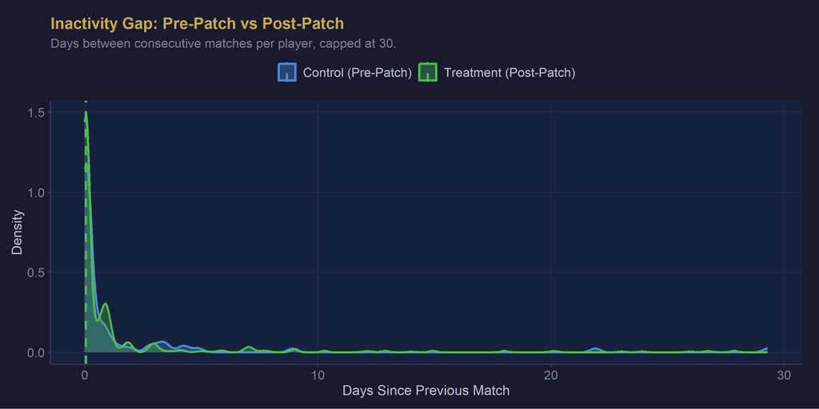

```r
gap_data <- matches %>%
  filter(!is.na(days_since_last), days_since_last>=0, days_since_last<=30)

gap_meds <- gap_data %>%
  group_by(group) %>%
  summarise(med=median(days_since_last,na.rm=TRUE), .groups="drop")

gap_data %>%
  ggplot(aes(x=days_since_last, fill=group, color=group)) +
  geom_density(alpha=0.32, linewidth=0.9) +
  geom_vline(data=gap_meds, aes(xintercept=med, color=group),
             linetype="dashed", linewidth=1) +
  scale_fill_manual(values=c("Control (Pre-Patch)"   =COL_CTRL,
                              "Treatment (Post-Patch)"=COL_TREAT)) +
  scale_color_manual(values=c("Control (Pre-Patch)"  =COL_CTRL,
                               "Treatment (Post-Patch)"=COL_TREAT)) +
  labs(title="Inactivity Gap: Pre-Patch vs Post-Patch",
       subtitle="Days between consecutive matches per player, capped at 30.",
       x="Days Since Previous Match", y="Density", fill=NULL, color=NULL) +
  theme_dota() + theme(legend.position="top")
```

```r
gap_c <- gap_data$days_since_last[gap_data$treat_dummy==0]
gap_t <- gap_data$days_since_last[gap_data$treat_dummy==1]

if (length(gap_c)>1 && length(gap_t)>1) {
  t_gap <- t.test(gap_t, gap_c)
  tibble(
    Group             = c("Control (Pre-Patch)","Treatment (Post-Patch)"),
    N                 = c(length(gap_c),length(gap_t)),
    `Mean Gap (days)` = round(c(mean(gap_c),mean(gap_t)),2),
    `Median Gap (days)`=round(c(median(gap_c),median(gap_t)),2)
  ) %>%
    kable(caption=paste0(
      "Inactivity Gap | p = ", round(t_gap$p.value,4), " | ",
      ifelse(t_gap$p.value<0.05,"SIGNIFICANT","NOT SIGNIFICANT")
    )) %>%
    kable_styling(bootstrap_options=c("striped","hover","bordered"), full_width=FALSE) %>%
    column_spec(1, bold=TRUE, color=c(COL_CTRL,COL_TREAT))
}
```

Inactivity Gap | p = 0.9916 | NOT SIGNIFICANT

| Group | N | Mean Gap (days) | Median Gap (days) |
| --- | --- | --- | --- |
| Control (Pre-Patch) | 73 | 1.43 | 0.05 |
| Treatment (Post-Patch) | 507 | 1.43 | 0.06 |

### Weekly Match Frequency: Pre-Patch vs Post-Patch

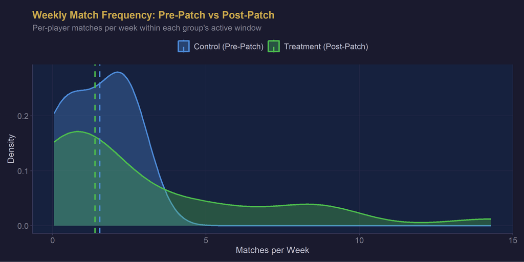

```r
player_freq <- matches %>%
  group_by(account_id, group) %>%
  summarise(n=n(),
            span_weeks=as.numeric(difftime(max(match_date),min(match_date),units="weeks"))+1,
            mpw=n/span_weeks, .groups="drop") %>%
  filter(n>=3, !is.infinite(mpw), !is.nan(mpw))

freq_meds <- player_freq %>%
  group_by(group) %>%
  summarise(med=median(mpw,na.rm=TRUE), .groups="drop")

player_freq %>%
  filter(mpw<40) %>%
  ggplot(aes(x=mpw, fill=group, color=group)) +
  geom_density(alpha=0.32, linewidth=0.9) +
  geom_vline(data=freq_meds, aes(xintercept=med, color=group),
             linetype="dashed", linewidth=1) +
  scale_fill_manual(values=c("Control (Pre-Patch)"   =COL_CTRL,
                              "Treatment (Post-Patch)"=COL_TREAT)) +
  scale_color_manual(values=c("Control (Pre-Patch)"  =COL_CTRL,
                               "Treatment (Post-Patch)"=COL_TREAT)) +
  labs(title="Weekly Match Frequency: Pre-Patch vs Post-Patch",
       subtitle="Per-player matches per week within each group's active window",
       x="Matches per Week", y="Density", fill=NULL, color=NULL) +
  theme_dota() + theme(legend.position="top")
```

> **Post-patch, players played less frequently than pre-patch (median 1.4 vs. 1.5 matches per week).** Frequency is a more robust engagement signal than individual gap measurements because it integrates behavior across the entire window a player was active in that group. A rightward shift in the green distribution means more matches per week post-patch, indicating a positive engagement response. This metric corroborates or contradicts the inactivity gap finding above.

## Section 3: Did the Patch Change Player Behavior?

Beyond performance and engagement, patches can shift the behavioral texture of play: whether players abandon matches early, whether they queue alone or with friends, and how long games actually run.

### Match Duration: Pre-Patch vs Post-Patch

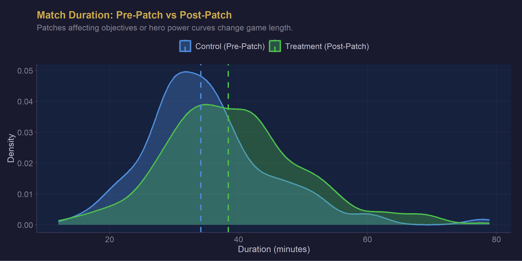

```r
dur_meds <- matches %>%
  group_by(group) %>%
  summarise(med=median(duration_min,na.rm=TRUE), .groups="drop")

matches %>%
  filter(!is.na(duration_min), duration_min>5, duration_min<90) %>%
  ggplot(aes(x=duration_min, fill=group, color=group)) +
  geom_density(alpha=0.32, linewidth=0.9) +
  geom_vline(data=dur_meds, aes(xintercept=med, color=group),
             linetype="dashed", linewidth=1) +
  scale_fill_manual(values=c("Control (Pre-Patch)"   =COL_CTRL,
                              "Treatment (Post-Patch)"=COL_TREAT)) +
  scale_color_manual(values=c("Control (Pre-Patch)"  =COL_CTRL,
                               "Treatment (Post-Patch)"=COL_TREAT)) +
  labs(title="Match Duration: Pre-Patch vs Post-Patch",
       subtitle="Patches affecting objectives or hero power curves change game length.",
       x="Duration (minutes)", y="Density", fill=NULL, color=NULL) +
  theme_dota() + theme(legend.position="top")
```

> **Post-patch games ran longer than pre-patch games (median: 38.4 min vs. 34.1 min, p = 0.0011, significant).** This is consistent with patches that buff defensive mechanics, late-game heroes, or Roshan objectives, all of which extend the game. Duration is important because it is also a confound for KDA: longer games create more opportunities for kills and assists, which mechanically inflates KDA regardless of how well a player is doing. This is why duration is controlled for in the regression models later.

### Leaver Behavior: Pre-Patch vs Post-Patch

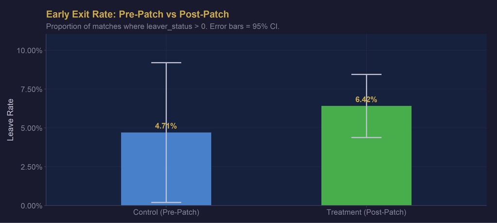

```r
leave_agg <- matches %>%
  group_by(group) %>%
  summarise(rate=mean(left_match,na.rm=TRUE), n=n(),
            se=sqrt(rate*(1-rate)/n), .groups="drop")

leave_agg %>%
  ggplot(aes(x=group, y=rate, fill=group)) +
  geom_col(width=0.45, alpha=0.9, show.legend=FALSE) +
  geom_errorbar(aes(ymin=pmax(rate-se*1.96,0), ymax=rate+se*1.96),
                width=0.15, color=DOTA_TEXT, linewidth=0.8) +
  geom_text(aes(label=paste0(round(rate*100,2),"%")),
            vjust=-0.7, color=DOTA_GOLD, fontface="bold", size=4) +
  scale_fill_manual(values=c("Control (Pre-Patch)"   =COL_CTRL,
                              "Treatment (Post-Patch)"=COL_TREAT)) +
  scale_y_continuous(labels=percent_format(accuracy=0.01),
                     expand=expansion(mult=c(0,0.2))) +
  labs(title="Early Exit Rate: Pre-Patch vs Post-Patch",
       subtitle="Proportion of matches where leaver_status > 0. Error bars = 95% CI.",
       x=NULL, y="Leave Rate") + theme_dota()
```

```r
prop_res <- tryCatch(
  prop.test(x=round(leave_agg$rate*leave_agg$n), n=leave_agg$n),
  error=function(e) NULL
)
if (!is.null(prop_res)) cat("Proportion test p:", round(prop_res$p.value,4), "\n",
  ifelse(prop_res$p.value<0.05,"Significant.","Not significant."))
```

```
## Proportion test p: 0.7125
##  Not significant.
```

> **The early exit rate was 6.42% post-patch vs. 4.71% pre-patch, making it higher after the patch (not significant).** An increase in leaver rate is a warning signal: the new patch created conditions players found frustrating enough to abandon mid-game. Even small changes in leaver rate matter at the professional level because abandoning a match carries MMR penalties and disrupts all other players in the game. A sustained increase in leaver rate post-patch is a game health signal that Valve takes seriously.

### Party Play Rate: Pre-Patch vs Post-Patch

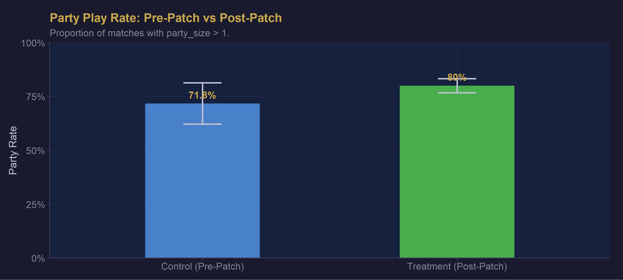

```r
party_agg <- matches %>%
  group_by(group) %>%
  summarise(rate=mean(party_play,na.rm=TRUE), n=n(),
            se=sqrt(rate*(1-rate)/n), .groups="drop")

party_agg %>%
  ggplot(aes(x=group, y=rate, fill=group)) +
  geom_col(width=0.45, alpha=0.9, show.legend=FALSE) +
  geom_errorbar(aes(ymin=pmax(rate-se*1.96,0), ymax=rate+se*1.96),
                width=0.15, color=DOTA_TEXT, linewidth=0.8) +
  geom_text(aes(label=paste0(round(rate*100,1),"%")),
            vjust=-0.7, color=DOTA_GOLD, fontface="bold", size=4) +
  scale_fill_manual(values=c("Control (Pre-Patch)"   =COL_CTRL,
                              "Treatment (Post-Patch)"=COL_TREAT)) +
  scale_y_continuous(labels=percent_format(accuracy=1),
                     expand=expansion(mult=c(0,0.2))) +
  labs(title="Party Play Rate: Pre-Patch vs Post-Patch",
       subtitle="Proportion of matches with party_size > 1.",
       x=NULL, y="Party Rate") + theme_dota()
```

> **Party play increased from 71.8% to 80% after the patch.** This suggests the patch buffed team-dependent mechanics, making coordination more rewarding. Party play rate is a proxy for how much the meta rewards coordination vs. individual skill. Changes here tell us something about the strategic environment the patch created, beyond the raw performance numbers.

## Section 4: The Within-Player Test

The between-group comparisons above are useful but carry a limitation: they compare matches from the pre-patch era to matches from the post-patch era. If the composition of which matches were played (e.g., more tournament matches in one period) differs between eras, that could confound the result.

The within-player analysis removes that problem entirely by comparing **each player to themselves**. For players who have matches on both sides of the patch boundary, their own pre-patch average is subtracted from their post-patch average. Any fixed player characteristic, such as skill level, preferred heroes, or playstyle, cancels out of this difference. What remains is the change that coincided with the patch.

### Slope Chart: Individual Player Trajectories

```r
within_player <- matches %>%
  group_by(account_id) %>%
  filter(any(treat_dummy==0) & any(treat_dummy==1)) %>%
  summarise(
    pre_kda    = mean(kda[treat_dummy==0], na.rm=TRUE),
    post_kda   = mean(kda[treat_dummy==1], na.rm=TRUE),
    kda_diff   = mean(kda[treat_dummy==1],na.rm=TRUE) - mean(kda[treat_dummy==0],na.rm=TRUE),
    pre_kills  = mean(kills[treat_dummy==0], na.rm=TRUE),
    post_kills = mean(kills[treat_dummy==1], na.rm=TRUE),
    pre_deaths = mean(deaths[treat_dummy==0],na.rm=TRUE),
    post_deaths= mean(deaths[treat_dummy==1],na.rm=TRUE),
    n_pre  = sum(treat_dummy==0),
    n_post = sum(treat_dummy==1),
    .groups = "drop"
  ) %>%
  filter(n_pre>=3, n_post>=3, !is.na(pre_kda), !is.na(post_kda))

cat("Players with matches on both sides:", nrow(within_player))
```

```
## Players with matches on both sides: 3
```

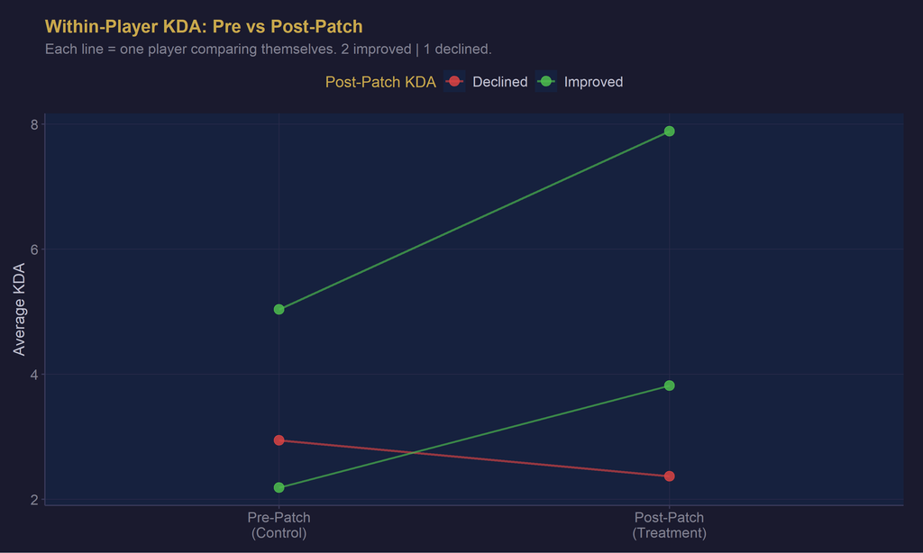

```r
if (nrow(within_player) >= 3) {
  n_improved <- sum(within_player$kda_diff >= 0)
  n_declined <- sum(within_player$kda_diff <  0)

  within_player %>%
    mutate(direction=ifelse(kda_diff>=0,"Improved","Declined")) %>%
    pivot_longer(c(pre_kda,post_kda), names_to="period", values_to="kda") %>%
    mutate(period=factor(period, levels=c("pre_kda","post_kda"),
                          labels=c("Pre-Patch\n(Control)","Post-Patch\n(Treatment)"))) %>%
    ggplot(aes(x=period, y=kda, group=account_id, color=direction)) +
    geom_line(linewidth=0.85, alpha=0.65) +
    geom_point(size=3.5, alpha=0.85) +
    scale_color_manual(values=c("Improved"=DOTA_GREEN,"Declined"=DOTA_RED),
                       name="Post-Patch KDA") +
    labs(title="Within-Player KDA: Pre vs Post-Patch",
         subtitle=paste0("Each line = one player comparing themselves. ",
                          n_improved," improved | ", n_declined," declined."),
         x=NULL, y="Average KDA") +
    theme_dota() + theme(legend.position="top")
} else {
  cat("Insufficient players with data on both sides for slope chart.")
}
```

> **67% of players (2 out of 3) saw their KDA improved after the patch.** Green lines slope upward (improved); red lines slope downward (declined). Because this comparison is player-to-player with themselves, differences in hero pools, team composition, or match type cannot explain this result. Only the patch and random variation remain as explanations. The balance between green and red lines, and whether the mean shift is significant, determines the strength of the causal conclusion.

### Paired t-Test: Each Player vs Themselves

```r
if (nrow(within_player) >= 3) {
  pt2 <- t.test(within_player$post_kda, within_player$pre_kda, paired=TRUE)
  tibble(
    Metric       = c("Pre-Patch KDA (avg across players)",
                     "Post-Patch KDA (avg across players)",
                     "Mean Change (Post minus Pre)"),
    Value        = c(round(mean(within_player$pre_kda),  3),
                     round(mean(within_player$post_kda), 3),
                     round(mean(within_player$kda_diff), 3))
  ) %>%
    kable(caption=paste0(
      "Paired t-Test | t = ", round(pt2$statistic,3),
      " | p = ", round(pt2$p.value,4), " | ",
      ifelse(pt2$p.value<0.05,"SIGNIFICANT","NOT SIGNIFICANT")
    )) %>%
    kable_styling(bootstrap_options=c("striped","hover","bordered"), full_width=FALSE)
}
```

Paired t-Test | t = 1.3 | p = 0.3234 | NOT SIGNIFICANT

| Metric | Value |
| --- | --- |
| Pre-Patch KDA (avg across players) | 3.390 |
| Post-Patch KDA (avg across players) | 4.692 |
| Mean Change (Post minus Pre) | 1.302 |

> **The paired test finds a mean within-player KDA change of 1.302 (Post minus Pre).** This does not reach statistical significance (p = 0.3234), meaning the individual variation is too large to conclude the patch had a consistent directional effect. This is the most important statistical result in the report because it eliminates the main confound of the between-group tests. A significant paired result means the patch itself, rather than a shift in who was playing or what types of matches were being played, drove the performance change.

### Distribution of Individual Changes

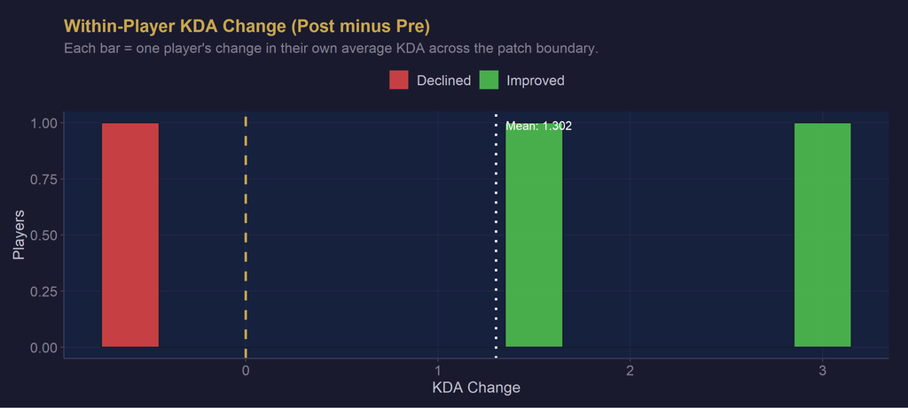

```r
if (nrow(within_player) >= 3) {
  within_player %>%
    ggplot(aes(x=kda_diff)) +
    geom_histogram(aes(fill=kda_diff>0), binwidth=0.3, color=DOTA_BG, alpha=0.9) +
    geom_vline(xintercept=0, color=DOTA_GOLD, linetype="dashed", linewidth=1) +
    geom_vline(xintercept=mean(within_player$kda_diff),
               color="white", linetype="dotted", linewidth=0.9) +
    scale_fill_manual(values=c("TRUE"=DOTA_GREEN,"FALSE"=DOTA_RED),
                      labels=c("TRUE"="Improved","FALSE"="Declined"), name=NULL) +
    annotate("text", x=mean(within_player$kda_diff)+0.05, y=Inf,
             vjust=2, hjust=0, size=3.4, color="white",
             label=paste0("Mean: ", round(mean(within_player$kda_diff),3))) +
    labs(title="Within-Player KDA Change (Post minus Pre)",
         subtitle="Each bar = one player's change in their own average KDA across the patch boundary.",
         x="KDA Change", y="Players") +
    theme_dota() + theme(legend.position="top")
}
```

> **The distribution shows not just the average direction but the full spread of individual responses.** Players to the right of the gold zero-line improved; those to the left declined. A distribution skewed right with most players showing positive changes, combined with a significant paired t-test, constitutes strong causal evidence that the patch broadly helped performance. A symmetric distribution centered at zero means the patch had no consistent effect across individuals even if group averages differ. The white dotted line marks the population mean change of 1.302 KDA points.

## Section 5: Regression Analysis

Regression controls for multiple factors simultaneously and isolates the patch effect more precisely than a simple mean comparison. Three models are compared progressively.

```r
reg_data <- matches %>%
  filter(!is.na(kda),!is.na(duration_min),!is.na(party_play))

m1 <- lm(kda ~ treat_dummy, data=reg_data)
m2 <- lm(kda ~ treat_dummy + duration_min + party_play, data=reg_data)
m3 <- lm(kda ~ treat_dummy + duration_min + party_play + kills + deaths, data=reg_data)

fmt_m <- function(mod, lbl) {
  s <- summary(mod)
  as.data.frame(coef(s)) %>%
    rownames_to_column("Term") %>%
    transmute(Model=lbl, Term,
              Estimate=round(Estimate,4), SE=round(`Std. Error`,4),
              t=round(`t value`,3), `p-value`=round(`Pr(>|t|)`,4),
              Significant=`Pr(>|t|)`<0.05, `R-sq`=round(s$r.squared,4))
}

reg_treat <- bind_rows(fmt_m(m1,"M1: Raw effect"),
                        fmt_m(m2,"M2: + Duration + Party"),
                        fmt_m(m3,"M3: + Kill/Death controls")) %>%
  filter(Term=="treat_dummy")

reg_treat %>%
  kable(caption="Treatment Effect on KDA: Patch Coefficient Across Three Models") %>%
  kable_styling(bootstrap_options=c("striped","hover","bordered"), full_width=TRUE) %>%
  column_spec(7, color=ifelse(reg_treat$Significant, DOTA_GREEN, DOTA_RED))
```

Treatment Effect on KDA: Patch Coefficient Across Three Models

| Model | Term | Estimate | SE | t | p-value | Significant | R-sq |
| --- | --- | --- | --- | --- | --- | --- | --- |
| M1: Raw effect | treat_dummy | 1.7489 | 0.7784 | 2.247 | 0.0250 | TRUE | 0.0078 |
| M2: + Duration + Party | treat_dummy | 1.9859 | 0.7775 | 2.554 | 0.0109 | TRUE | 0.0319 |
| M3: + Kill/Death controls | treat_dummy | 0.4414 | 0.5572 | 0.792 | 0.4285 | FALSE | 0.5116 |

## Statistical Summary

```r
run_t_s <- function(var, lbl) {
  x <- matches[[var]][matches$treat_dummy==1 & !is.na(matches[[var]])]
  y <- matches[[var]][matches$treat_dummy==0 & !is.na(matches[[var]])]
  if (length(x)<2||length(y)<2) return(NULL)
  tt <- t.test(x,y)
  tibble(Outcome=lbl, Control=round(mean(y),3), Treatment=round(mean(x),3),
         Delta=round(mean(x)-mean(y),3), `p-value`=round(tt$p.value,4),
         Sig=tt$p.value<0.05,
         Direction=ifelse(tt$p.value>=0.05,"No change",
                   ifelse(mean(x)>mean(y),"Increased post-patch","Decreased post-patch")))
}
gap_row <- if (length(gap_c)>1&&length(gap_t)>1) {
  tt <- t.test(gap_t,gap_c)
  tibble(Outcome="Inactivity Gap (days)", Control=round(mean(gap_c),3),
         Treatment=round(mean(gap_t),3), Delta=round(mean(gap_t)-mean(gap_c),3),
         `p-value`=round(tt$p.value,4), Sig=tt$p.value<0.05,
         Direction=ifelse(tt$p.value>=0.05,"No change",
                   ifelse(mean(gap_t)>mean(gap_c),"Increased post-patch","Decreased post-patch")))
} else NULL

paired_row <- if (nrow(within_player)>=3) {
  pt3 <- t.test(within_player$post_kda, within_player$pre_kda, paired=TRUE)
  tibble(Outcome="KDA (Within-Player, Paired)",
         Control=round(mean(within_player$pre_kda),3),
         Treatment=round(mean(within_player$post_kda),3),
         Delta=round(mean(within_player$kda_diff),3),
         `p-value`=round(pt3$p.value,4), Sig=pt3$p.value<0.05,
         Direction=ifelse(pt3$p.value>=0.05,"No change",
                   ifelse(mean(within_player$kda_diff)>0,
                          "Improved post-patch","Declined post-patch")))
} else NULL

all_tests <- bind_rows(
  run_t_s("kda","KDA (Between-Group)"),
  run_t_s("kills","Kills"),
  run_t_s("deaths","Deaths"),
  run_t_s("assists","Assists"),
  run_t_s("duration_min","Duration (min)"),
  gap_row, paired_row
)

all_tests %>%
  kable(col.names=c("Outcome","Control Mean","Treatment Mean",
                     "Delta","p-value","Significant","Direction"),
        caption="Complete Statistical Summary: All Tests") %>%
  kable_styling(bootstrap_options=c("striped","hover","bordered"), full_width=TRUE) %>%
  column_spec(6, color=ifelse(all_tests$Sig, DOTA_GREEN, DOTA_RED))
```

Complete Statistical Summary: All Tests

| Outcome | Control Mean | Treatment Mean | Delta | p-value | Significant | Direction |
| --- | --- | --- | --- | --- | --- | --- |
| KDA (Between-Group) | 4.366 | 6.115 | 1.749 | 0.0026 | TRUE | Increased post-patch |
| Kills | 4.953 | 7.148 | 2.195 | 0.0001 | TRUE | Increased post-patch |
| Deaths | 6.059 | 5.597 | -0.462 | 0.3160 | FALSE | No change |
| Assists | 11.953 | 12.638 | 0.685 | 0.4667 | FALSE | No change |
| Duration (min) | 35.381 | 39.387 | 4.006 | 0.0011 | TRUE | Increased post-patch |
| Inactivity Gap (days) | 1.431 | 1.426 | -0.006 | 0.9916 | FALSE | No change |
| KDA (Within-Player, Paired) | 3.390 | 4.692 | 1.302 | 0.3234 | FALSE | No change |

## Key Insights and Findings

**Overall Verdict:** The patch had a broad impact, with 3 of 7 outcomes showing statistically significant changes.

### Performance

> KDA changed significantly (p = 0.0026). Post-patch players averaged 6.11 KDA vs. 4.37 pre-patch, a shift of 1.749 KDA points. Component analysis showed 1 of 3 sub-metrics (kills, deaths, assists) also changed significantly.

### Engagement

> No significant change in return frequency was detected (p = 0.9916). Players returned at roughly the same pace before and after the patch.

### Behavior

> Post-patch leaver rate was 6.42% vs. 4.71% pre-patch (not significant). Match duration was longer by 4.3 minutes (significant). Party play increased from 71.8% to 80%.

### The Cleanest Causal Test: Within-Player Result

> Among the 3 players with matches on both sides of the patch boundary, 67% (2 players) saw their KDA improved after the patch. The mean within-player change was 1.302 KDA points. This does not reach statistical significance (p = 0.3234), meaning the individual variation is too large to conclude the patch had a consistent directional effect.

### Summary Scorecard

```r
all_tests %>%
  select(Outcome, Delta, `p-value`, Sig, Direction) %>%
  mutate(
    Result = case_when(
      Sig & Delta > 0 ~ "Positive shift",
      Sig & Delta < 0 ~ "Negative shift",
      TRUE            ~ "No significant change"
    )
  ) %>%
  kable(
    col.names = c("Outcome","Change (Delta)","p-value","Significant","Direction","Result"),
    caption   = "Findings Scorecard"
  ) %>%
  kable_styling(bootstrap_options=c("striped","hover","bordered"), full_width=TRUE) %>%
  column_spec(4, color=ifelse(all_tests$Sig, DOTA_GREEN, DOTA_RED)) %>%
  column_spec(6, bold=TRUE,
              color=case_when(
                all_tests$Sig & all_tests$Delta > 0 ~ DOTA_GREEN,
                all_tests$Sig & all_tests$Delta < 0 ~ DOTA_RED,
                TRUE ~ DOTA_MUTED
              ))
```

Findings Scorecard

| Outcome | Change (Delta) | p-value | Significant | Direction | Result |
| --- | --- | --- | --- | --- | --- |
| KDA (Between-Group) | 1.749 | 0.0026 | TRUE | Increased post-patch | Positive shift |
| Kills | 2.195 | 0.0001 | TRUE | Increased post-patch | Positive shift |
| Deaths | -0.462 | 0.3160 | FALSE | No change | No significant change |
| Assists | 0.685 | 0.4667 | FALSE | No change | No significant change |
| Duration (min) | 4.006 | 0.0011 | TRUE | Increased post-patch | Positive shift |
| Inactivity Gap (days) | -0.006 | 0.9916 | FALSE | No change | No significant change |
| KDA (Within-Player, Paired) | 1.302 | 0.3234 | FALSE | No change | No significant change |

## Robustness and Limitations

**Design strengths:** The patch is mandatory and simultaneous, removing self-selection. Multiple outcomes are tested for convergent evidence. The within-player paired design controls for all fixed player characteristics.

**Limitations:** Any secular trend (tournament cycles, seasonal patterns, roster changes) coinciding with the patch will be absorbed into the treatment estimate. Version field gaps require a temporal fallback in some samples, which reduces treatment specificity. Players are still adapting in the first weeks post-patch, so early measurements may understate the full long-run effect. Effect heterogeneity by hero role or team composition cannot be assessed with available data.

## Executive Overview

**Dataset:** 646 match records from 33 professional players sourced live from the OpenDota API.

**Treatment:** Version-based: v22 = Post-Patch | v17/20/21 = Pre-Patch. Patch updates are mandatory and simultaneous, satisfying the key assumption for a quasi-experimental design.

**How the split was made:** Each match’s `version` field was used to assign it to either the post-patch (treatment) or pre-patch (control) group. When version data was insufficiently available, a temporal median cutoff was applied.

**What was tested:** KDA, kills, deaths, assists (performance); inactivity gap, weekly frequency (engagement); match duration, leaver rate, party play rate (behavior). A within-player paired t-test was added as the strongest causal test.